# Análisis Exploratorio y Modelado del Dataset Heart Disease UCI

Jeriel

06 de agosto de 2026

```r
library(tidyverse)
library(readr)
library(knitr)
library(kableExtra)
library(GGally)
library(corrplot)
library(factoextra)
library(cluster)
library(DT)
library(scales)
```

# 1 Análisis Exploratorio y Modelado de Datos sobre Enfermedades Cardíacas

## 1.1 Heart Disease UCI Dataset

**Colegio Universitario de Cartago**

**Tecnologías de Información**

**Big Data BD-142**

**Profesora:** *Ronald Cordoba Vega*

**Estudiante:** Jeriel, Isaac,Roberto,Sebastian,Gabriel

**Fecha:** 06/08/2026

> **Objetivo del proyecto**

Desarrollar un análisis exploratorio y un proceso de modelado sobre el conjunto de datos **Heart Disease UCI**, con el fin de comprender las características clínicas de los pacientes, identificar patrones relevantes y aplicar técnicas de minería de datos que permitan obtener información útil para apoyar la toma de decisiones.

# 2 Introducción

El análisis de datos se ha convertido en una herramienta fundamental para apoyar la toma de decisiones en el ámbito de la salud. A través del estudio de grandes volúmenes de información clínica es posible identificar patrones, relaciones entre variables y factores que pueden contribuir al diagnóstico oportuno de diversas enfermedades.

Las enfermedades cardiovasculares representan una de las principales causas de muerte a nivel mundial, por lo que comprender los factores asociados con su aparición resulta de gran importancia para el desarrollo de estrategias de prevención, diagnóstico y tratamiento. En este contexto, la ciencia de datos permite analizar información proveniente de pacientes para descubrir tendencias que difícilmente podrían identificarse mediante una revisión manual.

El presente proyecto utiliza el conjunto de datos **Heart Disease UCI**, ampliamente utilizado en investigaciones y prácticas de análisis de datos, el cual reúne información clínica de pacientes evaluados por posible enfermedad cardíaca. A partir de este conjunto de datos se desarrollará un proceso completo de análisis exploratorio, limpieza, selección de variables y modelado mediante técnicas de minería de datos, con el propósito de identificar patrones relevantes y obtener información que facilite la comprensión del comportamiento de los pacientes.

Durante el desarrollo del proyecto se aplicarán diferentes técnicas de análisis exploratorio de datos (EDA), reducción de dimensionalidad mediante Análisis de Componentes Principales (PCA) y agrupamiento utilizando el algoritmo K-Means, permitiendo descubrir relaciones entre las variables y segmentar pacientes con características similares. Cada etapa será acompañada de un análisis e interpretación de los resultados obtenidos, buscando no solo ejecutar procedimientos estadísticos, sino también generar conocimiento útil a partir de los datos.

## 2.1 Objetivo General

Desarrollar un análisis exploratorio y un proceso de modelado sobre el conjunto de datos Heart Disease UCI, aplicando técnicas de ciencia de datos y minería de datos que permitan comprender las características de los pacientes, identificar patrones relevantes y obtener información útil para apoyar la toma de decisiones.

## 2.2 Objetivos Específicos

- Comprender la estructura y las características generales del conjunto de datos mediante un análisis preexploratorio.
- Identificar la calidad de los datos detectando valores faltantes, registros duplicados y posibles inconsistencias.
- Seleccionar las variables más relevantes para el análisis justificando su importancia dentro del estudio.
- Realizar un Análisis Exploratorio de Datos (EDA) utilizando estadísticas descriptivas y visualizaciones que permitan comprender el comportamiento de las variables.
- Aplicar el Análisis de Componentes Principales (PCA) para reducir la dimensionalidad del conjunto de datos y facilitar la interpretación de la información.
- Implementar el algoritmo de agrupamiento K-Means para identificar grupos de pacientes con características similares.
- Interpretar los resultados obtenidos en cada etapa del análisis, generando conclusiones que respondan a la pregunta de investigación planteada.

# 3 Pregunta de negocio

¿Es posible identificar patrones clínicos y grupos de pacientes con características similares que permitan comprender mejor la presencia de enfermedades cardíacas mediante técnicas de análisis exploratorio y aprendizaje no supervisado? # Análisis preexploratorio Antes de iniciar el análisis estadístico es necesario comprender el conjunto de datos con el que se trabajará. El análisis preexploratorio permite conocer el origen de la información, el tipo de variables disponibles, el objetivo del estudio y las posibles limitaciones que pueden presentarse durante el proceso de análisis.

Esta etapa facilita la planificación del trabajo, ya que permite definir las técnicas más adecuadas para el tratamiento de los datos y establecer una estrategia de análisis basada en las características del conjunto de datos. Además, ayuda a detectar desde el inicio posibles problemas de calidad, como valores faltantes, registros duplicados o variables con formatos incorrectos, evitando que estos afecten los resultados posteriores.

En las siguientes secciones se realizará una revisión general del conjunto de datos, describiendo su estructura, las variables que lo componen y los aspectos que serán considerados antes de iniciar el proceso de limpieza y análisis exploratorio.

# 4 Descripción del conjunto de datos

El conjunto de datos utilizado corresponde a información clínica relacionada con pacientes evaluados para determinar la presencia de enfermedad cardíaca.

El dataset contiene registros de pacientes con diferentes características demográficas, clínicas y resultados de pruebas médicas. Estas variables permiten analizar factores asociados con la presencia de enfermedad cardiovascular y encontrar patrones dentro de la población estudiada.

El conjunto de datos contiene **920 observaciones y 16 variables**, donde se incluyen variables numéricas y categóricas relacionadas con edad, sexo, presión arterial, colesterol, frecuencia cardíaca, resultados de pruebas clínicas y diagnóstico de enfermedad cardíaca.

La variable objetivo principal es `num`, la cual representa la presencia de enfermedad cardíaca con valores que van desde 0 hasta 4, donde valores mayores representan diferentes niveles de presencia de enfermedad.

Para efectos del análisis, esta variable fue transformada posteriormente en una clasificación binaria, donde: - 0 representa ausencia de enfermedad cardíaca. - Valores mayores que 0 representan presencia de enfermedad cardíaca.

Esta transformación permite realizar análisis comparativos y facilitar la interpretación de los resultados obtenidos durante las etapas exploratorias y de modelado. # Diccionario de variables

```r
diccionario <- data.frame(
  Variable = c(
    "id",
    "age",
    "sex",
    "dataset",
    "cp",
    "trestbps",
    "chol",
    "fbs",
    "restecg",
    "thalch",
    "exang",
    "oldpeak",
    "slope",
    "ca",
    "thal",
    "num"
  ),
  Descripcion = c(
    "Identificador único del paciente",
    "Edad del paciente en años",
    "Sexo del paciente",
    "Origen del conjunto de datos",
    "Tipo de dolor torácico presentado",
    "Presión arterial en reposo",
    "Nivel de colesterol sérico",
    "Presencia de glucemia en ayunas elevada",
    "Resultados del electrocardiograma en reposo",
    "Frecuencia cardíaca máxima alcanzada",
    "Presencia de angina inducida por ejercicio",
    "Depresión del segmento ST inducida por ejercicio",
    "Pendiente del segmento ST",
    "Cantidad de vasos principales observados mediante fluoroscopia",
    "Resultado de la prueba de talio",
    "Diagnóstico de enfermedad cardíaca"
  )
)

knitr::kable(
  diccionario,
  caption = "Diccionario de variables del conjunto de datos"
)
```

Diccionario de variables del conjunto de datos

| Variable | Descripcion |
| --- | --- |
| id | Identificador único del paciente |
| age | Edad del paciente en años |
| sex | Sexo del paciente |
| dataset | Origen del conjunto de datos |
| cp | Tipo de dolor torácico presentado |
| trestbps | Presión arterial en reposo |
| chol | Nivel de colesterol sérico |
| fbs | Presencia de glucemia en ayunas elevada |
| restecg | Resultados del electrocardiograma en reposo |
| thalch | Frecuencia cardíaca máxima alcanzada |
| exang | Presencia de angina inducida por ejercicio |
| oldpeak | Depresión del segmento ST inducida por ejercicio |
| slope | Pendiente del segmento ST |
| ca | Cantidad de vasos principales observados mediante fluoroscopia |
| thal | Resultado de la prueba de talio |
| num | Diagnóstico de enfermedad cardíaca |

# 5 Carga de datos

Antes de analizar cualquier conjunto de datos es indispensable cargar correctamente la información dentro del entorno de trabajo. Esta etapa permite verificar que el archivo pueda ser leído sin inconvenientes y que los datos se encuentren disponibles para su exploración y procesamiento.

Durante esta fase también se confirmará que el conjunto de datos fue importado correctamente, revisando su estructura general, dimensiones y los primeros registros. Esta verificación inicial es importante porque permite detectar errores de lectura, problemas con los nombres de las columnas o formatos incorrectos antes de iniciar el análisis.

```r
archivo <- file.choose()

heart <- read.csv(
  archivo,
  stringsAsFactors = FALSE
)

head(heart)
```

|  | id | age | sex | dataset | cp | trestbps | chol | fbs | restecg | thalch | exang | oldpeak | slope | ca | thal | num |
| --- | --- | --- | --- | --- | --- | --- | --- | --- | --- | --- | --- | --- | --- | --- | --- | --- |
| 1 | 1 | 63 | Male | Cleveland | typical angina | 145 | 233 | TRUE | lv hypertrophy | 150 | FALSE | 2.3 | downsloping | 0 | fixed defect | 0 |
| 2 | 2 | 67 | Male | Cleveland | asymptomatic | 160 | 286 | FALSE | lv hypertrophy | 108 | TRUE | 1.5 | flat | 3 | normal | 2 |
| 3 | 3 | 67 | Male | Cleveland | asymptomatic | 120 | 229 | FALSE | lv hypertrophy | 129 | TRUE | 2.6 | flat | 2 | reversable defect | 1 |
| 4 | 4 | 37 | Male | Cleveland | non-anginal | 130 | 250 | FALSE | normal | 187 | FALSE | 3.5 | downsloping | 0 | normal | 0 |
| 5 | 5 | 41 | Female | Cleveland | atypical angina | 130 | 204 | FALSE | lv hypertrophy | 172 | FALSE | 1.4 | upsloping | 0 | normal | 0 |
| 6 | 6 | 56 | Male | Cleveland | atypical angina | 120 | 236 | FALSE | normal | 178 | FALSE | 0.8 | upsloping | 0 | normal | 0 |

El conjunto de datos fue cargado correctamente en R, permitiendo disponer de toda la información necesaria para iniciar el análisis. La visualización inicial confirma que los registros fueron importados sin errores aparentes y que las columnas mantienen su estructura original. ## Análisis preexploratorio

Antes de iniciar el procesamiento y análisis del conjunto de datos, es necesario realizar una revisión inicial que permita comprender el contexto de la información disponible, el objetivo del estudio y las características generales que pueden influir en las etapas posteriores del proyecto.

El presente análisis utiliza el conjunto de datos **Heart Disease UCI**, el cual contiene información clínica de pacientes evaluados para determinar la presencia de enfermedad cardíaca. Cada registro representa un paciente y las variables disponibles corresponden a diferentes características demográficas, clínicas y médicas que pueden estar relacionadas con el estado de salud cardiovascular.

El objetivo principal del análisis es identificar patrones existentes dentro de la información médica disponible, comprender el comportamiento de las variables y aplicar técnicas de análisis exploratorio y modelado que permitan descubrir grupos de pacientes con características similares.

Antes de realizar cualquier transformación o construcción de modelos, se plantean algunas hipótesis iniciales que serán evaluadas durante el desarrollo del proyecto:

- Variables relacionadas con la edad podrían presentar diferencias entre pacientes con y sin presencia de enfermedad cardíaca, debido a que el riesgo cardiovascular suele aumentar con el envejecimiento.
- Variables clínicas como presión arterial, colesterol, frecuencia cardíaca máxima alcanzada y tipo de dolor torácico podrían presentar relaciones importantes dentro del análisis exploratorio.
- Las variables categóricas y numéricas requieren una revisión detallada, debido a que pueden necesitar transformaciones antes de aplicar técnicas estadísticas o algoritmos de agrupamiento.
- El conjunto de datos puede presentar problemas de calidad como valores faltantes, registros duplicados o formatos inconsistentes, por lo que será necesario realizar una evaluación posterior.

A partir de esta revisión inicial se establece la estrategia de análisis, la cual contempla una exploración descriptiva de los datos, evaluación de calidad, selección de variables relevantes y aplicación de técnicas de minería de datos para identificar patrones dentro de la población estudiada.

# 6 Exploración inicial

Una vez cargados los datos, es necesario realizar una exploración inicial que permita conocer la estructura general del conjunto de datos. Esta etapa ayuda a identificar el número de observaciones, la cantidad de variables disponibles y el tipo de dato asociado a cada una de ellas.

Comprender estas características facilita la planificación de las etapas posteriores de limpieza, transformación y análisis, ya que permite determinar cuáles variables son numéricas, categóricas o requieren algún tratamiento adicional.

```r
dim(heart)
```

```
## [1] 920  16
```

La función `dim()` permite conocer el tamaño del conjunto de datos, indicando el número de filas (observaciones) y columnas (variables). Esta información proporciona una visión general de la magnitud del análisis que se realizará.

```r
str(heart)
```

```
## 'data.frame':    920 obs. of  16 variables:
##  $ id      : int  1 2 3 4 5 6 7 8 9 10 ...
##  $ age     : int  63 67 67 37 41 56 62 57 63 53 ...
##  $ sex     : chr  "Male" "Male" "Male" "Male" ...
##  $ dataset : chr  "Cleveland" "Cleveland" "Cleveland" "Cleveland" ...
##  $ cp      : chr  "typical angina" "asymptomatic" "asymptomatic" "non-anginal" ...
##  $ trestbps: int  145 160 120 130 130 120 140 120 130 140 ...
##  $ chol    : int  233 286 229 250 204 236 268 354 254 203 ...
##  $ fbs     : logi  TRUE FALSE FALSE FALSE FALSE FALSE ...
##  $ restecg : chr  "lv hypertrophy" "lv hypertrophy" "lv hypertrophy" "normal" ...
##  $ thalch  : int  150 108 129 187 172 178 160 163 147 155 ...
##  $ exang   : logi  FALSE TRUE TRUE FALSE FALSE FALSE ...
##  $ oldpeak : num  2.3 1.5 2.6 3.5 1.4 0.8 3.6 0.6 1.4 3.1 ...
##  $ slope   : chr  "downsloping" "flat" "flat" "downsloping" ...
##  $ ca      : int  0 3 2 0 0 0 2 0 1 0 ...
##  $ thal    : chr  "fixed defect" "normal" "reversable defect" "normal" ...
##  $ num     : int  0 2 1 0 0 0 3 0 2 1 ...
```

La función `str()` muestra la estructura interna del conjunto de datos, indicando el nombre de cada variable, su tipo de dato y algunos valores de ejemplo. Esta revisión permite identificar variables numéricas y categóricas, además de detectar posibles conversiones que deberán realizarse durante la etapa de limpieza.

```r
names(heart)
```

```
##  [1] "id"       "age"      "sex"      "dataset"  "cp"       "trestbps"
##  [7] "chol"     "fbs"      "restecg"  "thalch"   "exang"    "oldpeak"
## [13] "slope"    "ca"       "thal"     "num"
```

Conocer el nombre de las variables facilita el desarrollo del análisis posterior, ya que permite identificar claramente la información disponible y planificar la selección de variables que serán utilizadas durante el modelado.

```r
head(heart)
```

|  | id | age | sex | dataset | cp | trestbps | chol | fbs | restecg | thalch | exang | oldpeak | slope | ca | thal | num |
| --- | --- | --- | --- | --- | --- | --- | --- | --- | --- | --- | --- | --- | --- | --- | --- | --- |
| 1 | 1 | 63 | Male | Cleveland | typical angina | 145 | 233 | TRUE | lv hypertrophy | 150 | FALSE | 2.3 | downsloping | 0 | fixed defect | 0 |
| 2 | 2 | 67 | Male | Cleveland | asymptomatic | 160 | 286 | FALSE | lv hypertrophy | 108 | TRUE | 1.5 | flat | 3 | normal | 2 |
| 3 | 3 | 67 | Male | Cleveland | asymptomatic | 120 | 229 | FALSE | lv hypertrophy | 129 | TRUE | 2.6 | flat | 2 | reversable defect | 1 |
| 4 | 4 | 37 | Male | Cleveland | non-anginal | 130 | 250 | FALSE | normal | 187 | FALSE | 3.5 | downsloping | 0 | normal | 0 |
| 5 | 5 | 41 | Female | Cleveland | atypical angina | 130 | 204 | FALSE | lv hypertrophy | 172 | FALSE | 1.4 | upsloping | 0 | normal | 0 |
| 6 | 6 | 56 | Male | Cleveland | atypical angina | 120 | 236 | FALSE | normal | 178 | FALSE | 0.8 | upsloping | 0 | normal | 0 |

La visualización de los primeros registros permite comprobar que los datos fueron cargados correctamente y ofrece una primera aproximación al contenido del conjunto de datos, facilitando la identificación de las variables clínicas que serán analizadas en las siguientes etapas.

# 7 Calidad de los datos

Antes de realizar cualquier análisis estadístico o aplicar técnicas de modelado, es fundamental evaluar la calidad del conjunto de datos. La presencia de valores faltantes, registros duplicados o inconsistencias en los formatos puede afectar la interpretación de los resultados y generar conclusiones incorrectas.

En esta etapa se realizará una revisión del conjunto de datos con el objetivo de identificar posibles problemas que requieran tratamiento previo. Se analizará la existencia de valores ausentes, la cantidad de registros duplicados y la estructura de las variables disponibles.

Esta evaluación permitirá determinar si el conjunto de datos requiere procesos adicionales de limpieza y transformación antes de continuar con el Análisis Exploratorio de Datos (EDA) y las técnicas de modelado.

```r
colSums(is.na(heart))
```

```
##       id      age      sex  dataset       cp trestbps     chol      fbs
##        0        0        0        0        0       59       30       90
##  restecg   thalch    exang  oldpeak    slope       ca     thal      num
##        0       55       55       62        0      611        0        0
```

La función `is.na()` permite identificar valores faltantes dentro del conjunto de datos, mientras que `colSums()` contabiliza la cantidad de valores ausentes por variable.

Este análisis permite conocer si existen columnas con información incompleta que puedan afectar las etapas posteriores del proyecto. En caso de encontrar valores faltantes, será necesario evaluar la estrategia adecuada para su tratamiento, considerando la naturaleza de cada variable. ### Interpretación de valores faltantes

El análisis de valores ausentes permitió identificar que el conjunto de datos presenta información incompleta en algunas variables clínicas.

Las variables con mayor cantidad de valores faltantes fueron:

- **ca** con 611 registros ausentes.
- **fbs** con 90 registros ausentes.
- **oldpeak** con 62 registros ausentes.
- **trestbps** con 59 registros ausentes.
- **thalch** y **exang** con 55 registros ausentes.
- **chol** con 30 registros ausentes.

La variable **ca** presenta una proporción elevada de valores faltantes respecto al total de observaciones (920 registros), por lo que deberá analizarse cuidadosamente antes de decidir si se elimina, se imputa o se excluye del modelado.

La presencia de valores faltantes en variables clínicas puede afectar los análisis estadísticos posteriores y la aplicación de algoritmos de aprendizaje automático, por lo que será necesario realizar un proceso de tratamiento de datos antes de construir los modelos.

Por otra parte, variables como `id`, `age`, `sex`, `dataset`, `cp`, `restecg`, `slope`, `thal` y `num` no presentan valores ausentes, lo cual indica una disponibilidad completa de información en estas características.

```r
sum(duplicated(heart))
```

```
## [1] 0
```

La función `duplicated()` permite identificar registros repetidos dentro del conjunto de datos. La presencia de duplicados puede generar una representación incorrecta de la población analizada, debido a que algunos pacientes podrían tener mayor peso dentro del análisis sin una justificación real.

El resultado obtenido permitirá determinar si es necesario eliminar registros duplicados antes de continuar con el procesamiento de los datos. ### Interpretación de registros duplicados

El análisis de duplicados identificó un total de **0 registros repetidos** dentro del conjunto de datos.

Este resultado indica que cada observación corresponde a un registro único dentro de la información analizada, evitando que determinados pacientes tengan una representación artificialmente mayor durante las etapas posteriores del análisis exploratorio y modelado.

Al no existir duplicados, no será necesario aplicar procesos de eliminación de registros repetidos.

```r
summary(heart)
```

```
##        id             age            sex              dataset
##  Min.   :  1.0   Min.   :28.00   Length:920         Length:920
##  1st Qu.:230.8   1st Qu.:47.00   Class :character   Class :character
##  Median :460.5   Median :54.00   Mode  :character   Mode  :character
##  Mean   :460.5   Mean   :53.51
##  3rd Qu.:690.2   3rd Qu.:60.00
##  Max.   :920.0   Max.   :77.00
##
##       cp               trestbps          chol          fbs
##  Length:920         Min.   :  0.0   Min.   :  0.0   Mode :logical
##  Class :character   1st Qu.:120.0   1st Qu.:175.0   FALSE:692
##  Mode  :character   Median :130.0   Median :223.0   TRUE :138
##                     Mean   :132.1   Mean   :199.1   NA's :90
##                     3rd Qu.:140.0   3rd Qu.:268.0
##                     Max.   :200.0   Max.   :603.0
##                     NA's   :59      NA's   :30
##    restecg              thalch        exang            oldpeak
##  Length:920         Min.   : 60.0   Mode :logical   Min.   :-2.6000
##  Class :character   1st Qu.:120.0   FALSE:528       1st Qu.: 0.0000
##  Mode  :character   Median :140.0   TRUE :337       Median : 0.5000
##                     Mean   :137.5   NA's :55        Mean   : 0.8788
##                     3rd Qu.:157.0                   3rd Qu.: 1.5000
##                     Max.   :202.0                   Max.   : 6.2000
##                     NA's   :55                      NA's   :62
##     slope                 ca             thal                num
##  Length:920         Min.   :0.0000   Length:920         Min.   :0.0000
##  Class :character   1st Qu.:0.0000   Class :character   1st Qu.:0.0000
##  Mode  :character   Median :0.0000   Mode  :character   Median :1.0000
##                     Mean   :0.6764                      Mean   :0.9957
##                     3rd Qu.:1.0000                      3rd Qu.:2.0000
##                     Max.   :3.0000                      Max.   :4.0000
##                     NA's   :611
```

La función `summary()` proporciona un resumen estadístico general de las variables del conjunto de datos. Para variables numéricas permite observar valores como mínimo, máximo, media y cuartiles, mientras que para variables categóricas muestra la distribución de sus categorías principales.

Esta revisión inicial ayuda a identificar valores extremos, rangos inesperados o categorías que puedan requerir transformación antes del modelado. ### Interpretación del resumen estadístico

El resumen general del conjunto de datos permite identificar las características principales de las variables disponibles.

El dataset contiene **920 registros de pacientes** y variables relacionadas con información demográfica y clínica. La variable `age` presenta un rango entre 28 y 77 años, con una edad promedio aproximada de 53 años, indicando que la población analizada corresponde principalmente a adultos de edad media y avanzada.

Entre las variables clínicas numéricas se observa que:

- La presión arterial en reposo (`trestbps`) presenta valores desde 0 hasta 200, con una media aproximada de 132.
- El colesterol (`chol`) presenta valores entre 0 y 603, con una media cercana a 199.
- La frecuencia cardíaca máxima alcanzada (`thalch`) tiene una media aproximada de 137 latidos por minuto.
- La variable `oldpeak`, relacionada con la depresión del segmento ST inducida por ejercicio, presenta valores entre -2.6 y 6.2.

Además, se observa que varias variables son de tipo categórico, como `sex`, `dataset`, `cp`, `restecg`, `slope` y `thal`, las cuales deberán ser transformadas adecuadamente si son utilizadas en modelos que requieran variables numéricas.

Los resultados obtenidos confirman que el conjunto de datos requiere una etapa posterior de limpieza y transformación antes de aplicar técnicas de análisis avanzado y modelado.

# 8 Limpieza y transformación

Luego de evaluar la calidad del conjunto de datos, se identificaron valores faltantes en algunas variables clínicas. Antes de realizar el análisis exploratorio y aplicar técnicas de modelado, es necesario realizar un proceso de limpieza y transformación que permita preparar la información para su correcto procesamiento.

La limpieza de datos busca corregir problemas identificados previamente, mientras que la transformación permite adaptar las variables al formato requerido por las técnicas estadísticas y algoritmos de aprendizaje automático.

En esta etapa se realizarán procedimientos relacionados con el tratamiento de valores ausentes, conversión de tipos de datos y preparación de variables para los análisis posteriores, procurando conservar la mayor cantidad de información posible.

```r
missing <- colSums(is.na(heart))

missing_percent <- round(
  (missing / nrow(heart)) * 100,
  2
)

missing_table <- data.frame(
  Variable = names(missing),
  Valores_Faltantes = missing,
  Porcentaje = missing_percent
)

missing_table
```

|  | Variable | Valores_Faltantes | Porcentaje |
| --- | --- | --- | --- |
| id | id | 0 | 0.00 |
| age | age | 0 | 0.00 |
| sex | sex | 0 | 0.00 |
| dataset | dataset | 0 | 0.00 |
| cp | cp | 0 | 0.00 |
| trestbps | trestbps | 59 | 6.41 |
| chol | chol | 30 | 3.26 |
| fbs | fbs | 90 | 9.78 |
| restecg | restecg | 0 | 0.00 |
| thalch | thalch | 55 | 5.98 |

[output cut: 6 more lines]

El cálculo del porcentaje de valores faltantes permite determinar la magnitud del problema en cada variable. Esta información será utilizada para decidir qué estrategia aplicar durante la limpieza de datos.

Las variables con pocos valores ausentes pueden ser tratadas mediante técnicas de imputación, mientras que aquellas con una proporción elevada deberán analizarse cuidadosamente para evitar introducir sesgos en el análisis. ### Interpretación del porcentaje de valores faltantes

El análisis porcentual de valores ausentes permitió identificar cuáles variables requieren tratamiento antes de continuar con las etapas de exploración y modelado.

Se observa que la mayoría de las variables presentan una cantidad baja o moderada de datos faltantes. Variables como `chol`, `trestbps`, `thalch`, `exang`, `oldpeak` y `fbs` presentan porcentajes inferiores al 10%, por lo que es posible aplicar estrategias de imputación que permitan conservar la mayor cantidad de registros disponibles.

La variable `ca` presenta un comportamiento diferente, con un total de 611 valores faltantes equivalentes al 66.41% del conjunto de datos. Este porcentaje representa una pérdida considerable de información, por lo que realizar una imputación podría introducir demasiada incertidumbre y afectar la calidad del análisis.

Debido a esta situación, la variable `ca` será evaluada posteriormente durante la selección de variables, considerando su aporte al análisis y la cantidad de información disponible.

A partir de estos resultados se establece que el conjunto de datos requiere un proceso de transformación previo al modelado, manteniendo la mayor cantidad de observaciones posibles y evitando eliminar registros completos innecesariamente.

```r
heart_clean <- heart
```

La creación de una copia del conjunto de datos permite conservar la información original sin modificaciones, trabajando sobre una versión preparada para las siguientes etapas del análisis.

Esta práctica permite comparar posteriormente los cambios realizados y evita la pérdida accidental de información durante el proceso de limpieza.

```r
heart_clean$trestbps[is.na(heart_clean$trestbps)] <-
  median(heart_clean$trestbps, na.rm = TRUE)

heart_clean$chol[is.na(heart_clean$chol)] <-
  median(heart_clean$chol, na.rm = TRUE)

heart_clean$thalch[is.na(heart_clean$thalch)] <-
  median(heart_clean$thalch, na.rm = TRUE)

heart_clean$oldpeak[is.na(heart_clean$oldpeak)] <-
  median(heart_clean$oldpeak, na.rm = TRUE)
```

La imputación mediante la mediana fue aplicada a las variables numéricas con valores faltantes moderados. Esta estrategia permite conservar los registros disponibles y reducir el impacto que podrían generar valores extremos, ya que la mediana es una medida robusta frente a distribuciones con posibles valores atípicos.

```r
heart_clean$fbs[is.na(heart_clean$fbs)] <-
  names(sort(table(heart_clean$fbs), decreasing = TRUE))[1]

heart_clean$exang[is.na(heart_clean$exang)] <-
  names(sort(table(heart_clean$exang), decreasing = TRUE))[1]
```

Las variables categóricas fueron completadas utilizando la categoría con mayor frecuencia dentro del conjunto de datos. Esta estrategia permite mantener la distribución original de las variables sin generar categorías artificiales.

```r
colSums(is.na(heart_clean))
```

```
##       id      age      sex  dataset       cp trestbps     chol      fbs
##        0        0        0        0        0        0        0        0
##  restecg   thalch    exang  oldpeak    slope       ca     thal      num
##        0        0        0        0        0      611        0        0
```

### 8.0.1 Verificación posterior al tratamiento de valores faltantes

Luego de aplicar las estrategias de imputación seleccionadas, se realizó una nueva revisión de valores ausentes para comprobar la efectividad del proceso de limpieza.

Los resultados muestran que las variables `trestbps`, `chol`, `fbs`, `thalch`, `exang` y `oldpeak` ya no presentan valores faltantes, permitiendo conservar la totalidad de los registros disponibles para los análisis posteriores.

La variable `ca` mantiene sus valores ausentes debido a que presenta una proporción elevada de datos faltantes (66.41%). En lugar de aplicar una imputación masiva que podría introducir información artificial, esta variable será evaluada posteriormente durante la selección de variables, donde se determinará si aporta suficiente información para ser incluida en los modelos.

```r
str(heart_clean)
```

```
## 'data.frame':    920 obs. of  16 variables:
##  $ id      : int  1 2 3 4 5 6 7 8 9 10 ...
##  $ age     : int  63 67 67 37 41 56 62 57 63 53 ...
##  $ sex     : chr  "Male" "Male" "Male" "Male" ...
##  $ dataset : chr  "Cleveland" "Cleveland" "Cleveland" "Cleveland" ...
##  $ cp      : chr  "typical angina" "asymptomatic" "asymptomatic" "non-anginal" ...
##  $ trestbps: int  145 160 120 130 130 120 140 120 130 140 ...
##  $ chol    : num  233 286 229 250 204 236 268 354 254 203 ...
##  $ fbs     : chr  "TRUE" "FALSE" "FALSE" "FALSE" ...
##  $ restecg : chr  "lv hypertrophy" "lv hypertrophy" "lv hypertrophy" "normal" ...
##  $ thalch  : int  150 108 129 187 172 178 160 163 147 155 ...
##  $ exang   : chr  "FALSE" "TRUE" "TRUE" "FALSE" ...
##  $ oldpeak : num  2.3 1.5 2.6 3.5 1.4 0.8 3.6 0.6 1.4 3.1 ...
##  $ slope   : chr  "downsloping" "flat" "flat" "downsloping" ...
##  $ ca      : int  0 3 2 0 0 0 2 0 1 0 ...
##  $ thal    : chr  "fixed defect" "normal" "reversable defect" "normal" ...
##  $ num     : int  0 2 1 0 0 0 3 0 2 1 ...
```

### 8.0.2 Interpretación de la estructura del conjunto limpio

La revisión de la estructura del conjunto de datos posterior al proceso de limpieza permitió identificar los tipos de variables disponibles y confirmar que las transformaciones iniciales fueron aplicadas correctamente.

El conjunto `heart_clean` contiene **920 observaciones y 16 variables**, manteniendo la totalidad de los registros originales.

Se identifican variables numéricas como:

- `age`: edad del paciente.
- `trestbps`: presión arterial en reposo.
- `chol`: nivel de colesterol.
- `thalch`: frecuencia cardíaca máxima alcanzada.
- `oldpeak`: depresión del segmento ST.
- `ca`: cantidad de vasos principales observados.
- `num`: variable asociada al diagnóstico de enfermedad cardíaca.

También se identifican variables categóricas almacenadas como texto (`character`), entre ellas:

- `sex`
- `dataset`
- `cp`
- `restecg`
- `slope`
- `thal`

Además, las variables `fbs` y `exang`, aunque representan condiciones binarias, fueron convertidas a formato texto durante el proceso de imputación, por lo que será necesario transformarlas posteriormente a un formato adecuado para análisis estadístico y modelado.

Esta revisión confirma que el conjunto está preparado para la siguiente etapa de transformación de variables, donde se realizarán las conversiones necesarias para adaptar la información a los algoritmos de análisis exploratorio y aprendizaje automático.

```r
heart_clean$fbs <- ifelse(heart_clean$fbs == "TRUE", 1, 0)

heart_clean$exang <- ifelse(heart_clean$exang == "TRUE", 1, 0)
```

```r
str(heart_clean)
```

```
## 'data.frame':    920 obs. of  16 variables:
##  $ id      : int  1 2 3 4 5 6 7 8 9 10 ...
##  $ age     : int  63 67 67 37 41 56 62 57 63 53 ...
##  $ sex     : chr  "Male" "Male" "Male" "Male" ...
##  $ dataset : chr  "Cleveland" "Cleveland" "Cleveland" "Cleveland" ...
##  $ cp      : chr  "typical angina" "asymptomatic" "asymptomatic" "non-anginal" ...
##  $ trestbps: int  145 160 120 130 130 120 140 120 130 140 ...
##  $ chol    : num  233 286 229 250 204 236 268 354 254 203 ...
##  $ fbs     : num  1 0 0 0 0 0 0 0 0 1 ...
##  $ restecg : chr  "lv hypertrophy" "lv hypertrophy" "lv hypertrophy" "normal" ...
##  $ thalch  : int  150 108 129 187 172 178 160 163 147 155 ...
##  $ exang   : num  0 1 1 0 0 0 0 1 0 1 ...
##  $ oldpeak : num  2.3 1.5 2.6 3.5 1.4 0.8 3.6 0.6 1.4 3.1 ...
##  $ slope   : chr  "downsloping" "flat" "flat" "downsloping" ...
##  $ ca      : int  0 3 2 0 0 0 2 0 1 0 ...
##  $ thal    : chr  "fixed defect" "normal" "reversable defect" "normal" ...
##  $ num     : int  0 2 1 0 0 0 3 0 2 1 ...
```

```r
heart_clean$heart_disease <- ifelse(heart_clean$num == 0, 0, 1)
```

```r
heart_clean$heart_disease <- ifelse(heart_clean$num == 0, 0, 1)

table(heart_clean$heart_disease)
```

```
##
##   0   1
## 411 509
```

### 8.0.3 Creación de la variable objetivo

La variable `num` del conjunto de datos representa diferentes niveles de enfermedad cardíaca, donde el valor **0** indica ausencia de enfermedad y los valores entre **1 y 4** representan distintos grados de presencia de la enfermedad.

Con el objetivo de facilitar la construcción de un modelo de clasificación, se creó una nueva variable denominada `heart_disease`, la cual agrupa los pacientes en dos categorías:

- **0:** Pacientes sin enfermedad cardíaca.
- **1:** Pacientes con presencia de enfermedad cardíaca.

Esta transformación permite construir modelos predictivos binarios, simplificando la interpretación de los resultados y facilitando la evaluación del desempeño mediante métricas como precisión, sensibilidad y matriz de confusión.

### 8.0.4 Interpretación de la variable objetivo

La creación de la variable `heart_disease` permitió transformar el problema original en una clasificación binaria, diferenciando a los pacientes con y sin presencia de enfermedad cardíaca.

La distribución obtenida muestra que el conjunto de datos contiene:

- **411 pacientes sin enfermedad cardíaca.**
- **509 pacientes con enfermedad cardíaca.**

Esta distribución es relativamente equilibrada, lo cual representa una ventaja para la construcción de modelos predictivos, ya que disminuye el riesgo de que el algoritmo favorezca una categoría sobre la otra.

A partir de esta transformación, la variable `heart_disease` será utilizada como variable objetivo en el modelo de clasificación, mientras que las demás variables clínicas actuarán como variables predictoras.

```r
heart_clean$sex <- as.factor(heart_clean$sex)
heart_clean$dataset <- as.factor(heart_clean$dataset)
heart_clean$cp <- as.factor(heart_clean$cp)
heart_clean$restecg <- as.factor(heart_clean$restecg)
heart_clean$slope <- as.factor(heart_clean$slope)
heart_clean$thal <- as.factor(heart_clean$thal)

str(heart_clean)
```

```
## 'data.frame':    920 obs. of  17 variables:
##  $ id           : int  1 2 3 4 5 6 7 8 9 10 ...
##  $ age          : int  63 67 67 37 41 56 62 57 63 53 ...
##  $ sex          : Factor w/ 2 levels "Female","Male": 2 2 2 2 1 2 1 1 2 2 ...
##  $ dataset      : Factor w/ 4 levels "Cleveland","Hungary",..: 1 1 1 1 1 1 1 1 1 1 ...
##  $ cp           : Factor w/ 4 levels "asymptomatic",..: 4 1 1 3 2 2 1 1 1 1 ...
##  $ trestbps     : int  145 160 120 130 130 120 140 120 130 140 ...
##  $ chol         : num  233 286 229 250 204 236 268 354 254 203 ...
##  $ fbs          : num  1 0 0 0 0 0 0 0 0 1 ...
##  $ restecg      : Factor w/ 4 levels "","lv hypertrophy",..: 2 2 2 3 2 3 2 3 2 2 ...
##  $ thalch       : int  150 108 129 187 172 178 160 163 147 155 ...
##  $ exang        : num  0 1 1 0 0 0 0 1 0 1 ...
##  $ oldpeak      : num  2.3 1.5 2.6 3.5 1.4 0.8 3.6 0.6 1.4 3.1 ...
##  $ slope        : Factor w/ 4 levels "","downsloping",..: 2 3 3 2 4 4 2 4 3 2 ...
##  $ ca           : int  0 3 2 0 0 0 2 0 1 0 ...
##  $ thal         : Factor w/ 4 levels "","fixed defect",..: 2 3 4 3 3 3 3 3 4 4 ...
##  $ num          : int  0 2 1 0 0 0 3 0 2 1 ...
##  $ heart_disease: num  0 1 1 0 0 0 1 0 1 1 ...
```

### 8.0.5 Conversión de variables categóricas

Las variables categóricas fueron convertidas al tipo `factor`, ya que este formato es el más apropiado para representar categorías dentro de R.

La utilización de factores permite que los modelos estadísticos y de aprendizaje automático interpreten correctamente cada categoría como un nivel independiente, evitando tratarlas como texto y facilitando la construcción de modelos predictivos.

Con esta transformación, el conjunto de datos queda preparado para las etapas de análisis exploratorio y modelado.

# 9 Selección de variables

La selección de variables constituye una etapa fundamental antes del análisis exploratorio y el modelado, ya que permite identificar aquellas características que aportan información relevante para responder al objetivo del proyecto.

La decisión de incluir o excluir variables se basó en criterios de utilidad clínica, calidad de los datos y aporte al análisis. Se descartaron variables que funcionan únicamente como identificadores o que presentan una cantidad excesiva de valores faltantes, mientras que se conservaron aquellas relacionadas con las características demográficas y clínicas de los pacientes.

La siguiente tabla resume la decisión tomada para cada una de las variables del conjunto de datos.

```r
seleccion_variables <- data.frame(
  Variable = c(
    "id", "age", "sex", "dataset", "cp", "trestbps",
    "chol", "fbs", "restecg", "thalch", "exang",
    "oldpeak", "slope", "ca", "thal", "heart_disease"
  ),
  Decision = c(
    "No", "Sí", "Sí", "No", "Sí", "Sí",
    "Sí", "Sí", "Sí", "Sí", "Sí",
    "Sí", "Sí", "No", "Sí", "Sí"
  ),
  Justificacion = c(
    "Identificador único del paciente.",
    "Factor de riesgo cardiovascular.",
    "Permite analizar diferencias por sexo.",
    "Indica únicamente el origen del registro.",
    "Variable clínica relacionada con síntomas.",
    "Indicador importante de presión arterial.",
    "Relacionado con el riesgo cardiovascular.",
    "Antecedente clínico relevante.",
    "Describe la actividad eléctrica del corazón.",
    "Indicador del rendimiento cardíaco.",
    "Relacionada con síntomas inducidos por ejercicio.",
    "Mide alteraciones durante el esfuerzo.",
    "Describe el comportamiento del segmento ST.",
    "Presenta 66.41% de valores faltantes.",
    "Información clínica relevante.",
    "Variable objetivo para el modelo predictivo."
  )
)

kable(
  seleccion_variables,
  caption = "Selección de variables para el análisis"
) |>
  kable_styling(
    bootstrap_options = c("striped", "hover", "condensed"),
    full_width = FALSE
  )
```

Selección de variables para el análisis

| Variable | Decision | Justificacion |
| --- | --- | --- |
| id | No | Identificador único del paciente. |
| age | Sí | Factor de riesgo cardiovascular. |
| sex | Sí | Permite analizar diferencias por sexo. |
| dataset | No | Indica únicamente el origen del registro. |
| cp | Sí | Variable clínica relacionada con síntomas. |
| trestbps | Sí | Indicador importante de presión arterial. |
| chol | Sí | Relacionado con el riesgo cardiovascular. |
| fbs | Sí | Antecedente clínico relevante. |
| restecg | Sí | Describe la actividad eléctrica del corazón. |
| thalch | Sí | Indicador del rendimiento cardíaco. |
| exang | Sí | Relacionada con síntomas inducidos por ejercicio. |
| oldpeak | Sí | Mide alteraciones durante el esfuerzo. |
| slope | Sí | Describe el comportamiento del segmento ST. |
| ca | No | Presenta 66.41% de valores faltantes. |
| thal | Sí | Información clínica relevante. |
| heart_disease | Sí | Variable objetivo para el modelo predictivo. |

### 9.0.1 Interpretación de la selección de variables

La selección realizada permitió conservar únicamente aquellas variables con utilidad clínica y capacidad para aportar información durante el análisis exploratorio y el modelado.

Las variables `id` y `dataset` fueron excluidas debido a que no representan características propias del paciente. La primera corresponde únicamente a un identificador, mientras que la segunda indica el hospital o base de datos de procedencia de cada registro.

Asimismo, la variable `ca` fue excluida del análisis debido a que presenta un **66.41% de valores faltantes**, porcentaje que podría afectar significativamente la confiabilidad de los modelos si se intentara imputar la información.

Las variables restantes contienen información demográfica y clínica relevante, por lo que serán utilizadas tanto en el análisis exploratorio de datos como en los modelos de agrupamiento y predicción desarrollados en las siguientes etapas del proyecto.

# 10 Análisis Exploratorio de Datos (EDA)

El análisis exploratorio de datos tiene como propósito comprender el comportamiento de las variables, identificar patrones, detectar posibles anomalías y generar conocimiento previo al modelado. En esta etapa se estudian tanto las variables de forma individual como las relaciones existentes entre ellas.

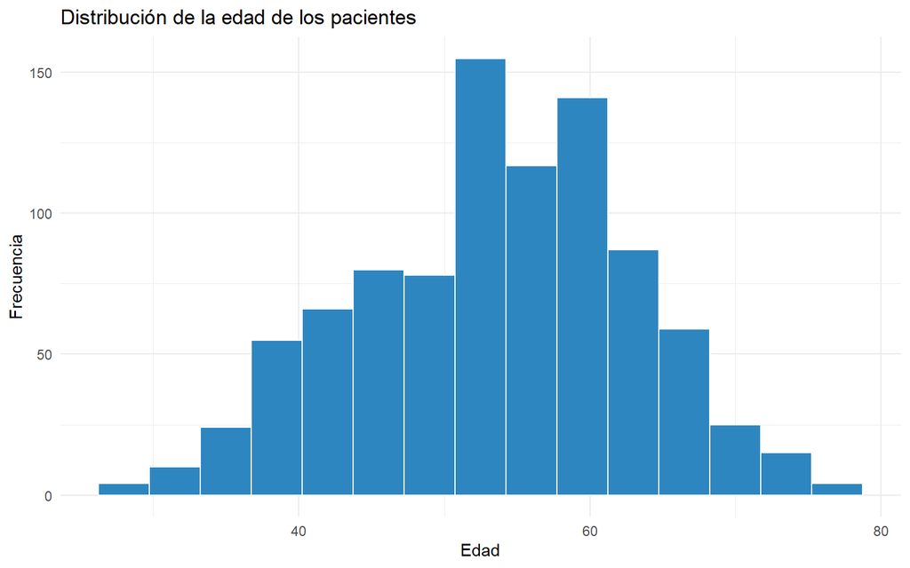

```r
ggplot(heart_clean, aes(x = age)) +
  geom_histogram(
    bins = 15,
    fill = "#2E86C1",
    color = "white"
  ) +
  labs(
    title = "Distribución de la edad de los pacientes",
    x = "Edad",
    y = "Frecuencia"
  ) +
  theme_minimal()
```

### Interpretación

La distribución de la edad permite identificar el grupo poblacional predominante dentro del conjunto de datos. Este análisis resulta especialmente importante debido a que la edad constituye uno de los principales factores de riesgo asociados con enfermedades cardiovasculares.

El histograma permitirá observar si los registros se concentran en determinados rangos de edad o si existe una distribución uniforme entre los pacientes analizados. Esta información servirá posteriormente para interpretar la relación entre la edad y la presencia de enfermedad cardíaca.

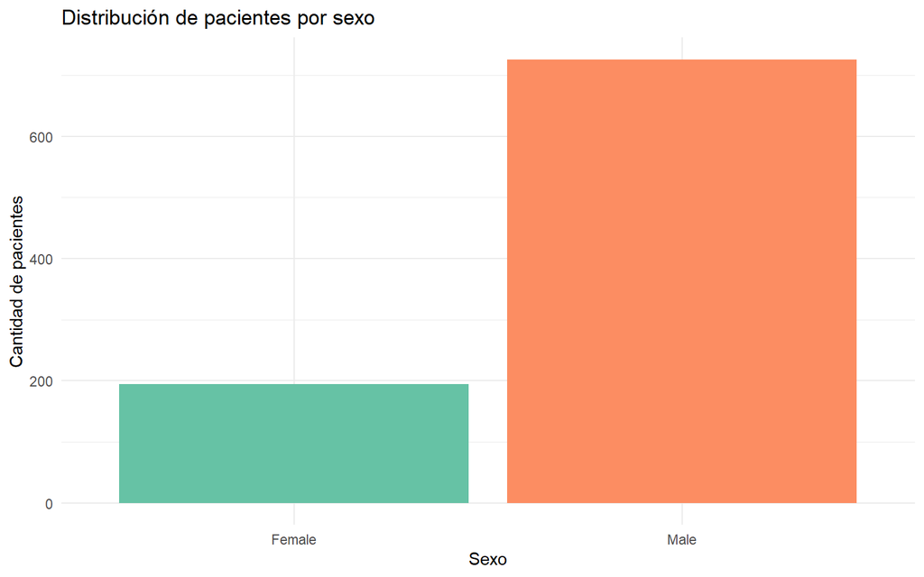

```r
ggplot(heart_clean, aes(x = sex, fill = sex)) +
  geom_bar() +
  labs(
    title = "Distribución de pacientes por sexo",
    x = "Sexo",
    y = "Cantidad de pacientes"
  ) +
  scale_fill_brewer(palette = "Set2") +
  theme_minimal() +
  theme(legend.position = "none")
```

### 10.0.1 Interpretación

La distribución por sexo permite conocer la composición demográfica del conjunto de datos. Este análisis facilita identificar si existe una representación equilibrada entre hombres y mujeres o si alguno de los grupos predomina dentro de la muestra.

La presencia de un mayor número de pacientes de un determinado sexo puede influir en los resultados del análisis exploratorio y del modelo predictivo, por lo que resulta importante documentar esta característica desde el inicio.

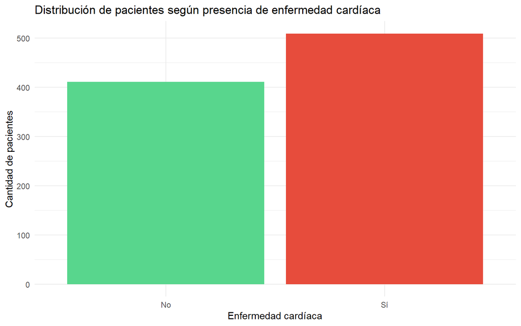

```r
ggplot(heart_clean, aes(x = factor(heart_disease), fill = factor(heart_disease))) +
  geom_bar() +
  labs(
    title = "Distribución de pacientes según presencia de enfermedad cardíaca",
    x = "Enfermedad cardíaca",
    y = "Cantidad de pacientes"
  ) +
  scale_x_discrete(labels = c("No", "Sí")) +
  scale_fill_manual(values = c("#58D68D", "#E74C3C")) +
  theme_minimal() +
  theme(legend.position = "none")
```

### Interpretación

Este gráfico presenta la distribución de la variable objetivo utilizada para el modelo predictivo. Se observa la cantidad de pacientes con y sin enfermedad cardíaca, permitiendo verificar si ambas categorías presentan una distribución balanceada.

Una distribución relativamente equilibrada favorece la construcción de modelos de clasificación, ya que reduce el riesgo de obtener resultados sesgados hacia una única categoría.

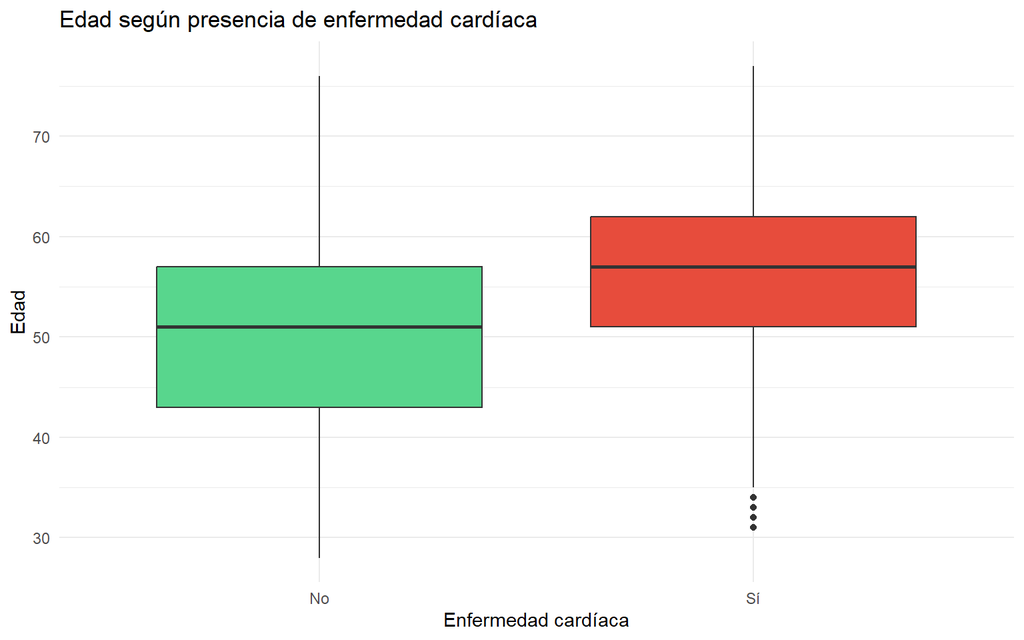

```r
ggplot(heart_clean,
       aes(x = factor(heart_disease),
           y = age,
           fill = factor(heart_disease))) +
  geom_boxplot() +
  labs(
    title = "Edad según presencia de enfermedad cardíaca",
    x = "Enfermedad cardíaca",
    y = "Edad"
  ) +
  scale_x_discrete(labels = c("No", "Sí")) +
  scale_fill_manual(values = c("#58D68D", "#E74C3C")) +
  theme_minimal() +
  theme(legend.position = "none")
```

### Interpretación

El diagrama de cajas permite comparar la distribución de edades entre los pacientes con y sin enfermedad cardíaca.

Este análisis facilita identificar diferencias en la mediana, la dispersión y la presencia de valores atípicos entre ambos grupos. En caso de observarse edades mayores en los pacientes con enfermedad, ello respaldaría la importancia de la edad como factor asociado al riesgo cardiovascular.

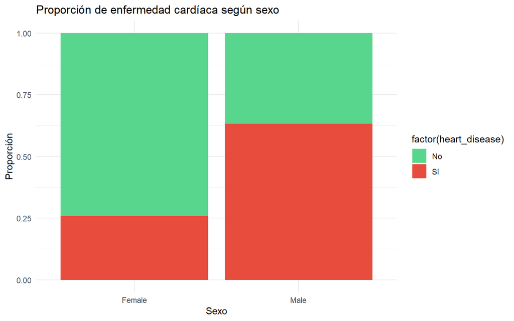

```r
ggplot(heart_clean,
       aes(x = sex,
           fill = factor(heart_disease))) +
  geom_bar(position = "fill") +
  labs(
    title = "Proporción de enfermedad cardíaca según sexo",
    x = "Sexo",
    y = "Proporción"
  ) +
  scale_fill_manual(
    values = c("#58D68D", "#E74C3C"),
    labels = c("No", "Sí")
  ) +
  theme_minimal()
```

### Interpretación

Este gráfico compara la proporción de pacientes con y sin enfermedad cardíaca según el sexo.

El análisis permite determinar si alguno de los grupos presenta una mayor frecuencia relativa de enfermedad, aportando evidencia sobre posibles diferencias demográficas dentro del conjunto de datos.

```r
heart_clean$cp <- factor(
  heart_clean$cp,
  levels = c(
    "asymptomatic",
    "atypical angina",
    "non-anginal",
    "typical angina"
  ),
  labels = c(
    "Asintomático",
    "Angina atípica",
    "No anginoso",
    "Angina típica"
  )
)
```

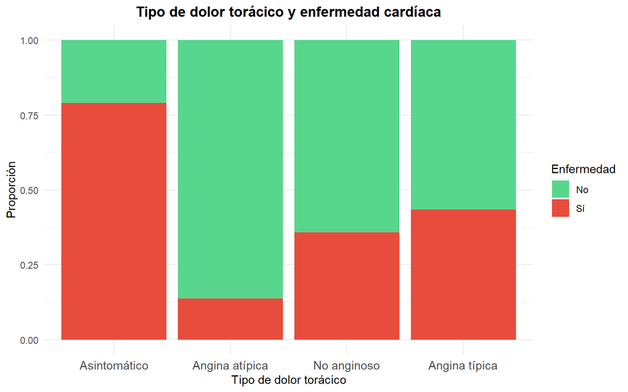

```r
ggplot(heart_clean,
       aes(cp, fill = factor(heart_disease))) +
  geom_bar(position = "fill") +
  labs(
    title = "Tipo de dolor torácico y enfermedad cardíaca",
    x = "Tipo de dolor torácico",
    y = "Proporción",
    fill = "Enfermedad"
  ) +
  scale_fill_manual(
    values = c("#58D68D", "#E74C3C"),
    labels = c("No", "Sí")
  ) +
  theme_minimal() +
  theme(
    axis.text.x = element_text(size = 11),
    plot.title = element_text(hjust = 0.5, face = "bold")
  )
```

### Interpretación

El tipo de dolor torácico constituye una de las variables clínicas con mayor relevancia para el diagnóstico de enfermedades cardíacas.

El gráfico permite observar si determinados tipos de dolor presentan una mayor proporción de pacientes con enfermedad, proporcionando evidencia sobre su posible capacidad predictiva dentro del conjunto de datos. ## Relación entre colesterol y enfermedad cardíaca

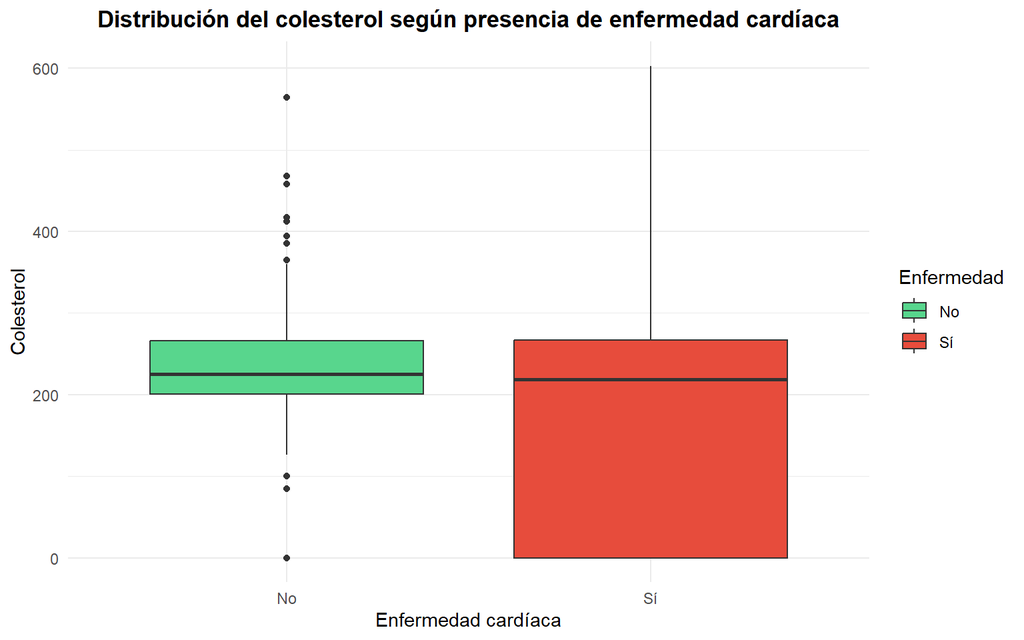

```r
ggplot(heart_clean,
       aes(x = factor(heart_disease),
           y = chol,
           fill = factor(heart_disease))) +
  geom_boxplot() +
  labs(
    title = "Distribución del colesterol según presencia de enfermedad cardíaca",
    x = "Enfermedad cardíaca",
    y = "Colesterol",
    fill = "Enfermedad"
  ) +
  scale_x_discrete(labels = c("No", "Sí")) +
  scale_fill_manual(
    values = c("#58D68D", "#E74C3C"),
    labels = c("No", "Sí")
  ) +
  theme_minimal() +
  theme(
    plot.title = element_text(hjust = 0.5, face = "bold"),
    legend.position = "right"
  )
```

### Interpretación

El colesterol es una variable clínica relevante debido a su relación con enfermedades cardiovasculares.

El diagrama de cajas permite comparar los niveles de colesterol entre pacientes con y sin enfermedad cardíaca, observando diferencias en la distribución, valores centrales y posibles valores extremos.

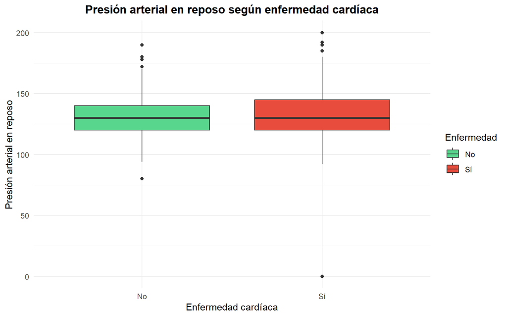

```r
ggplot(heart_clean,
       aes(x = factor(heart_disease),
           y = trestbps,
           fill = factor(heart_disease))) +
  geom_boxplot() +
  labs(
    title = "Presión arterial en reposo según enfermedad cardíaca",
    x = "Enfermedad cardíaca",
    y = "Presión arterial en reposo",
    fill = "Enfermedad"
  ) +
  scale_x_discrete(labels = c("No", "Sí")) +
  scale_fill_manual(
    values = c("#58D68D", "#E74C3C"),
    labels = c("No", "Sí")
  ) +
  theme_minimal() +
  theme(
    plot.title = element_text(hjust = 0.5, face = "bold")
  )
```

### Interpretación

La presión arterial en reposo (`trestbps`) representa una característica clínica importante dentro del diagnóstico cardiovascular.

La comparación mediante diagramas de caja permite identificar diferencias entre pacientes con y sin enfermedad cardíaca, observando la tendencia central y dispersión de los valores registrados.

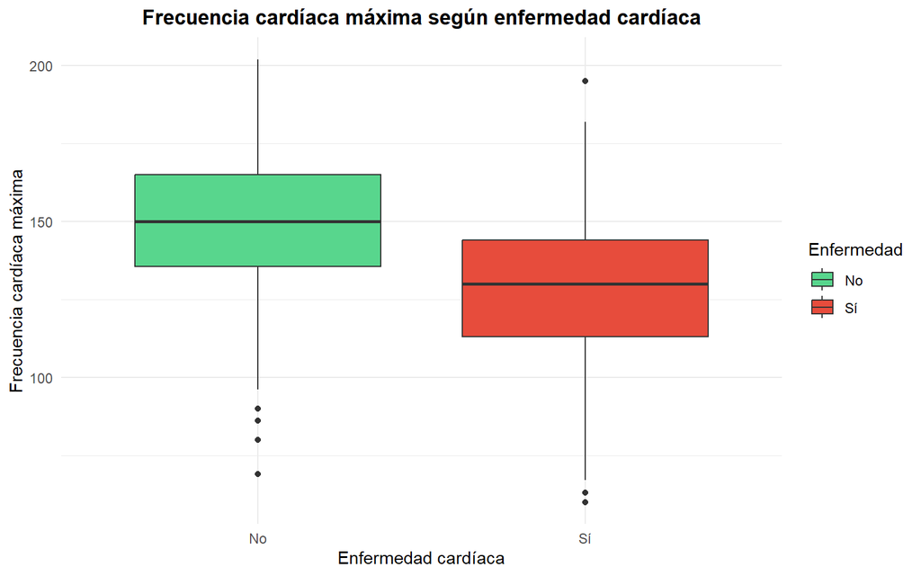

```r
ggplot(heart_clean,
       aes(x = factor(heart_disease),
           y = thalch,
           fill = factor(heart_disease))) +
  geom_boxplot() +
  labs(
    title = "Frecuencia cardíaca máxima según enfermedad cardíaca",
    x = "Enfermedad cardíaca",
    y = "Frecuencia cardíaca máxima",
    fill = "Enfermedad"
  ) +
  scale_x_discrete(labels = c("No", "Sí")) +
  scale_fill_manual(
    values = c("#58D68D", "#E74C3C"),
    labels = c("No", "Sí")
  ) +
  theme_minimal() +
  theme(
    plot.title = element_text(hjust = 0.5, face = "bold")
  )
```

### Interpretación

La frecuencia cardíaca máxima alcanzada durante la prueba de esfuerzo permite evaluar la respuesta cardiovascular del paciente.

El análisis comparativo permite observar diferencias entre grupos y determinar si esta variable presenta patrones asociados con la presencia de enfermedad cardíaca.

Debido a su naturaleza clínica, esta variable será considerada posteriormente dentro de las etapas de selección final y modelado predictivo.

```r
variables_numericas <- heart_clean %>%
  select(
    age,
    trestbps,
    chol,
    thalch,
    oldpeak,
    ca,
    heart_disease
  )

head(variables_numericas)
```

|  | age | trestbps | chol | thalch | oldpeak | ca | heart_disease |
| --- | --- | --- | --- | --- | --- | --- | --- |
| 1 | 63 | 145 | 233 | 150 | 2.3 | 0 | 0 |
| 2 | 67 | 160 | 286 | 108 | 1.5 | 3 | 1 |
| 3 | 67 | 120 | 229 | 129 | 2.6 | 2 | 1 |
| 4 | 37 | 130 | 250 | 187 | 3.5 | 0 | 0 |
| 5 | 41 | 130 | 204 | 172 | 1.4 | 0 | 0 |
| 6 | 56 | 120 | 236 | 178 | 0.8 | 0 | 0 |

### 10.0.2 Selección de variables numéricas

Para el análisis de correlación se seleccionaron únicamente las variables cuantitativas del conjunto de datos.

Las variables consideradas fueron:

- `age`: edad del paciente.
- `trestbps`: presión arterial en reposo.
- `chol`: nivel de colesterol.
- `thalch`: frecuencia cardíaca máxima alcanzada.
- `oldpeak`: depresión del segmento ST.
- `ca`: número de vasos principales observados.
- `heart_disease`: variable objetivo creada para el modelo predictivo.

Esta selección permite evaluar posibles relaciones lineales entre características clínicas y la presencia de enfermedad cardíaca.

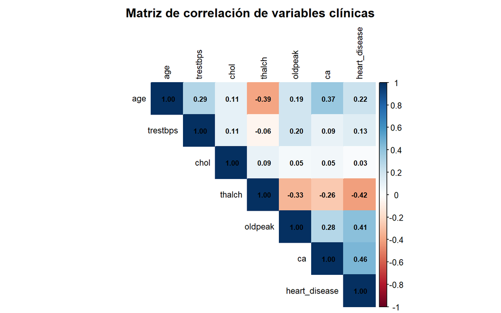

```r
matriz_cor <- cor(
  variables_numericas,
  use = "complete.obs"
)

corrplot(
  matriz_cor,
  method = "color",
  type = "upper",
  tl.col = "black",
  tl.cex = 0.8,
  addCoef.col = "black",
  number.cex = 0.7,
  title = "Matriz de correlación de variables clínicas",
  mar = c(0,0,2,0)
)
```

### Interpretación de la matriz de correlación

La matriz de correlación permite observar la intensidad y dirección de las relaciones lineales entre las variables numéricas del conjunto de datos.

Los valores cercanos a **1** representan relaciones positivas fuertes, mientras que los valores cercanos a **-1** representan relaciones negativas fuertes. Valores cercanos a **0** indican poca relación lineal entre las variables.

Este análisis permite identificar variables con comportamientos similares y detectar posibles relaciones relevantes para la etapa de modelado.

En particular, la relación de las variables clínicas con `heart_disease` proporciona una primera aproximación sobre cuáles características podrían tener mayor influencia en la clasificación de pacientes.

La matriz de correlación permitió analizar la relación existente entre las variables clínicas numéricas y la presencia de enfermedad cardíaca.

Los resultados muestran que la variable con mayor relación positiva respecto a la variable objetivo `heart_disease` fue `ca`, con una correlación de **0.46**, indicando que una mayor cantidad de vasos principales afectados se encuentra asociada con una mayor presencia de enfermedad cardíaca.

De igual forma, la variable `oldpeak` presentó una correlación positiva moderada de **0.41**, sugiriendo que mayores alteraciones del segmento ST pueden estar relacionadas con una mayor probabilidad de enfermedad.

Por otra parte, la variable `thalch` presentó una correlación negativa de **-0.42**, indicando que menores valores de frecuencia cardíaca máxima alcanzada tienden a aparecer con mayor frecuencia en pacientes con enfermedad cardíaca.

La variable `age` presentó una relación positiva débil (**0.22**), lo cual indica que la edad tiene cierta asociación con la presencia de enfermedad, aunque su efecto individual no es suficiente para explicar el diagnóstico.

Finalmente, la variable `chol` mostró una correlación muy baja (**0.03**), por lo que no presenta una relación lineal importante con la variable objetivo. Sin embargo, debido a su relevancia clínica, será considerada junto con otras variables dentro del análisis multivariable.

En general, la matriz de correlación evidencia que la enfermedad cardíaca no depende de una única característica, sino de la combinación de múltiples factores clínicos, justificando la utilización de modelos predictivos posteriores.

## 10.1 Análisis de valores atípicos

La identificación de valores atípicos permite evaluar la presencia de observaciones extremas dentro de las variables numéricas.

En un contexto médico, los valores extremos no necesariamente representan errores de medición, ya que pueden corresponder a pacientes con condiciones clínicas particulares. Por esta razón, los valores atípicos serán analizados, pero no eliminados automáticamente, conservando la información original del paciente.

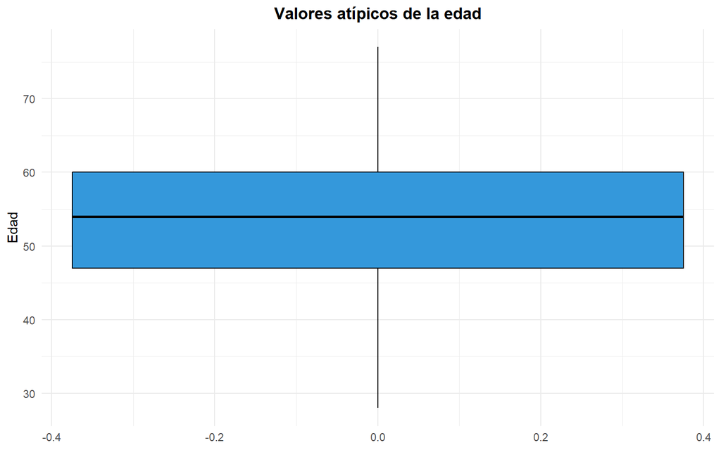

```r
ggplot(heart_clean, aes(y = age)) +
  geom_boxplot(
    fill = "#3498DB",
    color = "black"
  ) +
  labs(
    title = "Valores atípicos de la edad",
    y = "Edad"
  ) +
  theme_minimal() +
  theme(
    plot.title = element_text(
      hjust = 0.5,
      face = "bold"
    )
  )
```

### Interpretación

El análisis de la variable edad permite identificar si existen pacientes con edades alejadas del comportamiento general de la muestra.

Los posibles valores extremos observados representan pacientes pertenecientes a rangos de edad específicos y no necesariamente corresponden a errores. Por este motivo, se mantienen dentro del conjunto de datos para conservar la variabilidad clínica.

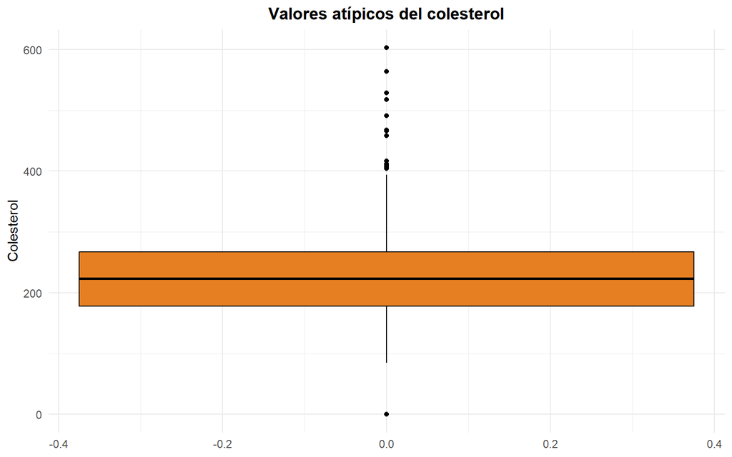

```r
ggplot(heart_clean, aes(y = chol)) +
  geom_boxplot(
    fill = "#E67E22",
    color = "black"
  ) +
  labs(
    title = "Valores atípicos del colesterol",
    y = "Colesterol"
  ) +
  theme_minimal() +
  theme(
    plot.title = element_text(
      hjust = 0.5,
      face = "bold"
    )
  )
```

### Interpretación

La variable colesterol presenta variabilidad entre los pacientes evaluados. La presencia de valores alejados del rango central puede representar individuos con niveles elevados o reducidos de colesterol.

Debido a que estos valores poseen significado clínico, no se eliminan del análisis. En su lugar, serán considerados durante la construcción de los modelos predictivos.

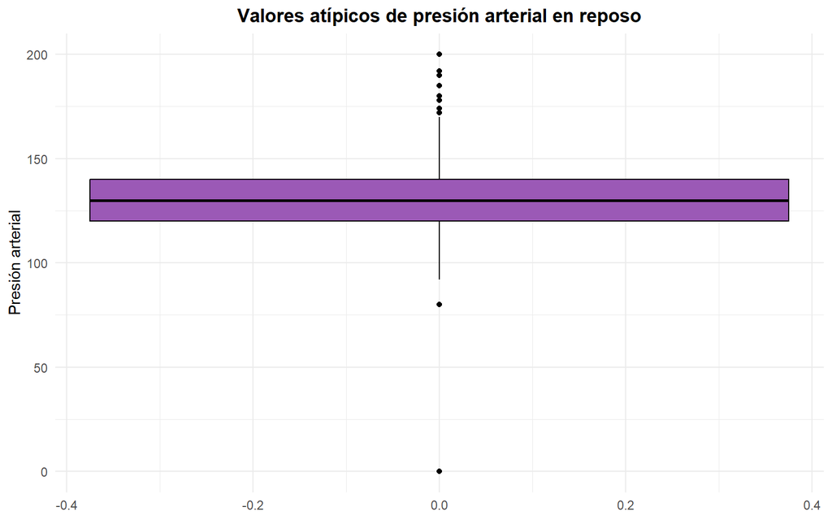

```r
ggplot(heart_clean, aes(y = trestbps)) +
  geom_boxplot(
    fill = "#9B59B6",
    color = "black"
  ) +
  labs(
    title = "Valores atípicos de presión arterial en reposo",
    y = "Presión arterial"
  ) +
  theme_minimal() +
  theme(
    plot.title = element_text(
      hjust = 0.5,
      face = "bold"
    )
  )
```

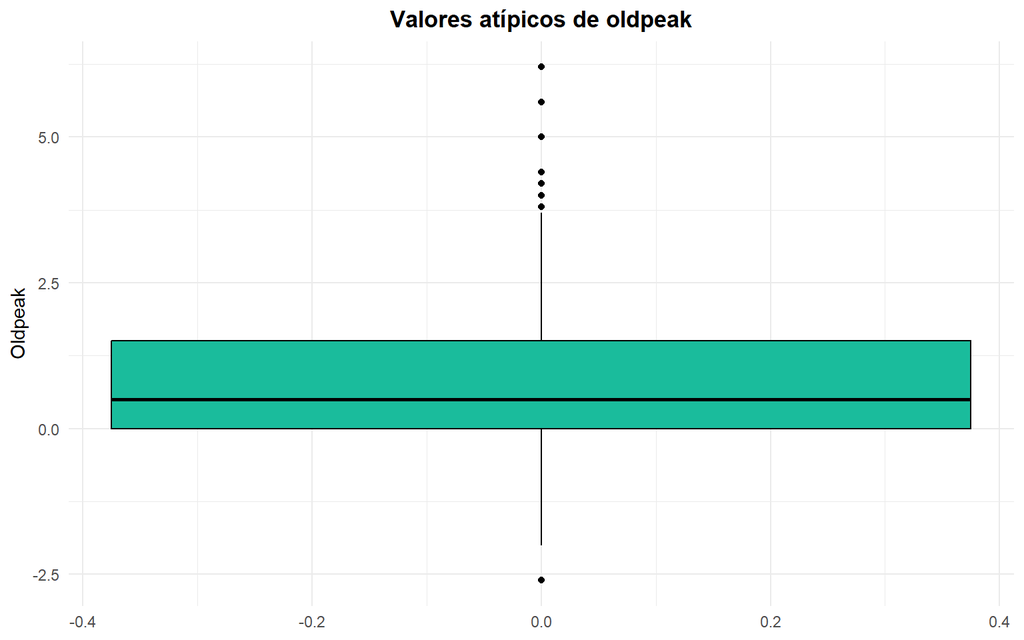

```r
ggplot(heart_clean, aes(y = oldpeak)) +
  geom_boxplot(
    fill = "#1ABC9C",
    color = "black"
  ) +
  labs(
    title = "Valores atípicos de oldpeak",
    y = "Oldpeak"
  ) +
  theme_minimal() +
  theme(
    plot.title = element_text(
      hjust = 0.5,
      face = "bold"
    )
  )
```

### Interpretación

La variable `oldpeak` presenta valores distribuidos en diferentes rangos, incluyendo algunos casos alejados del comportamiento central.

Estos valores representan respuestas fisiológicas particulares durante pruebas cardíacas, por lo que no deben ser considerados automáticamente como errores.

La decisión adoptada es conservar estas observaciones, permitiendo que los modelos posteriores aprendan patrones asociados con diferentes condiciones clínicas.

### 10.1.2 Interpretación general de valores atípicos

El análisis mediante diagramas de caja permitió evaluar la presencia de valores extremos en las principales variables numéricas del conjunto de datos.

Debido a la naturaleza clínica del conjunto de datos, estos valores no fueron eliminados, ya que podrían representar pacientes con características cardiovasculares particulares y aportar información relevante para los modelos predictivos.

El análisis exploratorio permitió comprender las principales características del conjunto de datos de pacientes con enfermedades cardíacas, identificando patrones relevantes antes de la construcción de modelos predictivos.

Durante el análisis se observó que la variable objetivo presenta una distribución equilibrada entre pacientes con y sin enfermedad cardíaca, favoreciendo la construcción de modelos de clasificación.

Las relaciones exploradas mostraron que variables clínicas como el tipo de dolor torácico, la frecuencia cardíaca máxima alcanzada, `oldpeak` y la cantidad de vasos afectados presentan comportamientos diferenciadores entre ambos grupos.

El análisis de correlación permitió identificar que variables como `ca`, `oldpeak` y `thalch` presentan las asociaciones lineales más relevantes con la presencia de enfermedad cardíaca. Sin embargo, también se confirmó que la enfermedad cardiovascular depende de múltiples factores combinados y no de una única variable.

El análisis de valores atípicos mostró la presencia de algunos registros extremos, pero en cantidades reducidas. Debido al contexto médico, estas observaciones fueron conservadas para evitar perder información clínica importante.

Las variables incluidas fueron:

- Edad.
- Presión arterial en reposo.
- Colesterol.
- Frecuencia cardíaca máxima.
- Depresión del segmento ST.
- Número de vasos principales afectados.

Estas variables fueron seleccionadas debido a que representan características fisiológicas relevantes y permiten reducir la dimensionalidad conservando información importante del paciente.

```r
# Imputación de valores faltantes en la variable ca

heart_clean$ca[is.na(heart_clean$ca)] <-
  median(heart_clean$ca, na.rm = TRUE)

# Verificación de valores faltantes después de la limpieza

colSums(is.na(heart_clean))
```

```
##            id           age           sex       dataset            cp
##             0             0             0             0             0
##      trestbps          chol           fbs       restecg        thalch
##             0             0             0             0             0
##         exang       oldpeak         slope            ca          thal
##             0             0             0             0             0
##           num heart_disease
##             0             0
```

```r
# Selección de variables numéricas para el análisis PCA

pca_data <- heart_clean %>%
  select(
    age,
    trestbps,
    chol,
    thalch,
    oldpeak,
    ca
  )

head(pca_data)
```

|  | age | trestbps | chol | thalch | oldpeak | ca |
| --- | --- | --- | --- | --- | --- | --- |
| 1 | 63 | 145 | 233 | 150 | 2.3 | 0 |
| 2 | 67 | 160 | 286 | 108 | 1.5 | 3 |
| 3 | 67 | 120 | 229 | 129 | 2.6 | 2 |
| 4 | 37 | 130 | 250 | 187 | 3.5 | 0 |
| 5 | 41 | 130 | 204 | 172 | 1.4 | 0 |
| 6 | 56 | 120 | 236 | 178 | 0.8 | 0 |

```r
# Verificación de calidad de los datos antes del PCA

colSums(is.na(pca_data))
```

```
##      age trestbps     chol   thalch  oldpeak       ca
##        0        0        0        0        0        0
```

```r
sum(is.infinite(as.matrix(pca_data)))
```

```
## [1] 0
```

```r
# Estandarización de variables para el análisis PCA

pca_scaled <- scale(pca_data)

head(pca_scaled)
```

```
##             age   trestbps       chol     thalch     oldpeak         ca
## [1,]  1.0068379  0.7047930 0.30347811  0.4894609  1.36736535 -0.3612033
## [2,]  1.4312553  1.5177439 0.78953751 -1.1808357  0.61125649  4.4087538
## [3,]  1.4312553 -0.6501250 0.26679438 -0.3456874  1.65090618  2.8187681
## [4,] -1.7518749 -0.1081578 0.45938395  1.9609126  2.50152865 -0.3612033
## [5,] -1.3274576 -0.1081578 0.03752107  1.3643781  0.51674288 -0.3612033
## [6,]  0.2641075 -0.6501250 0.33099090  1.6029919 -0.05033877 -0.3612033
```

```r
# Aplicación del Análisis de Componentes Principales

pca_model <- prcomp(
  pca_scaled,
  center = TRUE,
  scale. = TRUE
)

summary(pca_model)
```

```
## Importance of components:
##                           PC1    PC2    PC3    PC4    PC5     PC6
## Standard deviation     1.3087 1.1483 0.9766 0.8770 0.8354 0.74024
## Proportion of Variance 0.2854 0.2198 0.1590 0.1282 0.1163 0.09133
## Cumulative Proportion  0.2854 0.5052 0.6642 0.7923 0.9087 1.00000
```

### 10.1.3 Tratamiento de valores faltantes para PCA

Debido a que el análisis de componentes principales requiere una matriz completa de datos, fue necesario tratar los valores faltantes restantes en la variable `ca`.

Se aplicó imputación mediante la mediana, debido a que esta medida es robusta frente a valores extremos y permite conservar la totalidad de los registros del conjunto de datos.

Esta transformación permitió obtener una matriz adecuada para la aplicación del algoritmo PCA.

```r
colSums(is.na(pca_data))
```

```
##      age trestbps     chol   thalch  oldpeak       ca
##        0        0        0        0        0        0
```

### 10.1.4 Interpretación de los componentes principales

El análisis de componentes principales permitió reducir la dimensionalidad del conjunto de datos mediante la transformación de las variables clínicas originales en nuevas variables no correlacionadas denominadas componentes principales.

Los resultados muestran que la primera componente principal (PC1) explica el **28.54%** de la variabilidad total del conjunto de datos, mientras que la segunda componente (PC2) aporta un **21.98%** adicional. En conjunto, ambas componentes representan aproximadamente el **50.52%** de la información disponible.

Al considerar las tres primeras componentes principales se alcanza una representación del **66.42%** de la variabilidad, mientras que utilizando cuatro componentes se conserva aproximadamente el **79.23%**.

Para la visualización gráfica y la identificación de patrones mediante técnicas de agrupamiento, se utilizarán principalmente las dos primeras componentes principales, debido a que permiten representar los pacientes en un espacio bidimensional manteniendo una proporción importante de la información original.

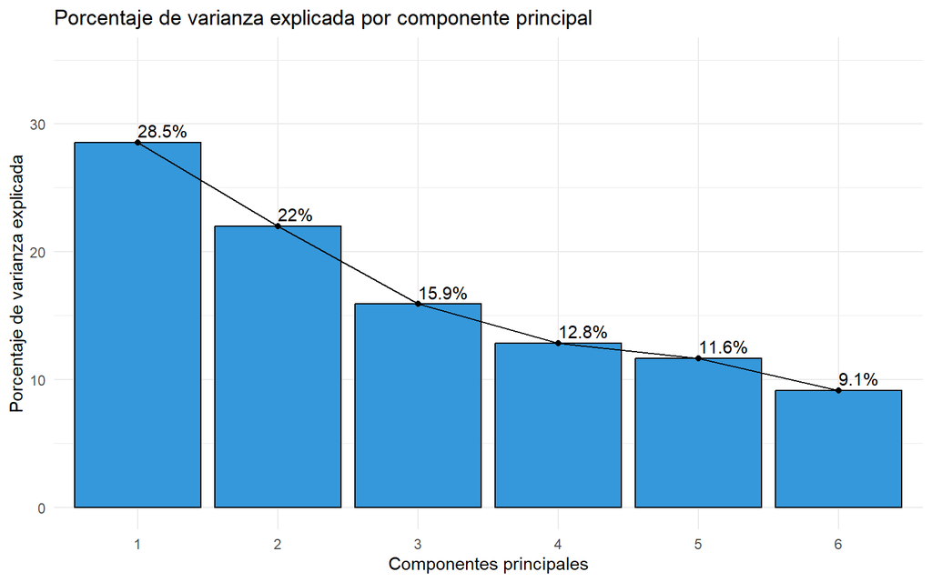

```r
library(factoextra)

fviz_eig(
  pca_model,
  addlabels = TRUE,
  ylim = c(0, 35),
  barfill = "#3498DB",
  barcolor = "black"
) +
  labs(
    title = "Porcentaje de varianza explicada por componente principal",
    x = "Componentes principales",
    y = "Porcentaje de varianza explicada"
  ) +
  theme_minimal()
```

## Visualización de pacientes mediante componentes principales

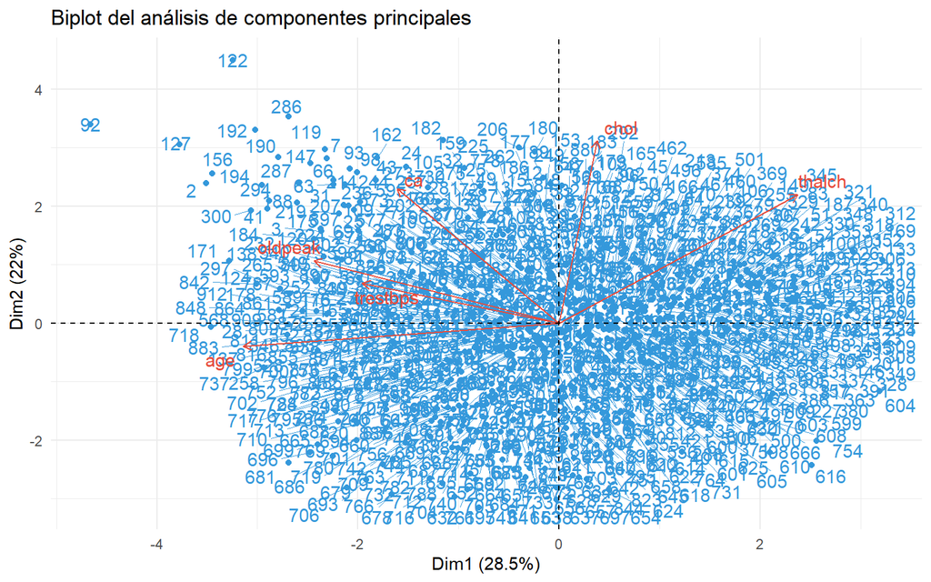

```r
fviz_pca_biplot(
  pca_model,
  repel = TRUE,
  col.var = "#E74C3C",
  col.ind = "#3498DB",
  title = "Biplot del análisis de componentes principales"
) +
  theme_minimal()
```

### Interpretación del biplot PCA

El biplot permite representar simultáneamente la distribución de los pacientes y la contribución de las variables originales dentro del espacio generado por las dos primeras componentes principales.

Las flechas representan la dirección e influencia de cada variable sobre los componentes. Una mayor longitud indica una mayor contribución dentro de la representación reducida.

La distribución de los pacientes permite observar posibles patrones o agrupamientos naturales dentro del conjunto de datos. Sin embargo, la separación visual no garantiza la existencia de grupos definidos, por lo que posteriormente se aplicará el algoritmo K-Means para identificar agrupaciones de manera cuantitativa.

Este análisis proporciona una representación visual previa que facilita la interpretación de los grupos encontrados durante el modelado no supervisado.

# 11 Modelado mediante K-Means

```r
pca_scores <- as.data.frame(
  pca_model$x[,1:2]
)

head(pca_scores)
```

|  | PC1 | PC2 |
| --- | --- | --- |
| 1 | -1.1367241 | 0.5878923 |
| 2 | -3.5087988 | 2.3919838 |
| 3 | -2.3641081 | 1.5686460 |
| 4 | 0.9488557 | 1.7640882 |
| 5 | 1.3138841 | 0.7079735 |
| 6 | 0.9594556 | 0.6720666 |

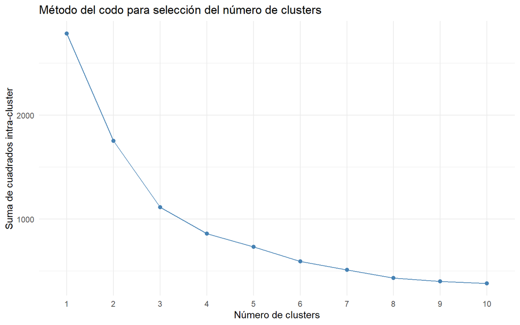

```r
fviz_nbclust(
  pca_scores,
  kmeans,
  method = "wss"
) +
  labs(
    title = "Método del codo para selección del número de clusters",
    x = "Número de clusters",
    y = "Suma de cuadrados intra-cluster"
  ) +
  theme_minimal()
```

## Selección del número óptimo de clústeres

Para determinar el número adecuado de grupos se utilizó el método del codo (Within-Cluster Sum of Squares - WSS).

Este método evalúa la variación interna de los grupos para diferentes valores de K. El número óptimo de clústeres se identifica en el punto donde la reducción del error comienza a disminuir significativamente.

El gráfico obtenido muestra una reducción importante hasta aproximadamente **K = 3**, momento a partir del cual la mejora adicional es menor. Por esta razón, se seleccionaron **3 clústeres** para la segmentación de pacientes.

```r
set.seed(123)

kmeans_model <- kmeans(
  pca_scores,
  centers = 3,
  nstart = 25
)

kmeans_model
```

```
## K-means clustering with 3 clusters of sizes 398, 292, 230
##
## Cluster means:
##          PC1        PC2
## 1  1.1569060  0.2560764
## 2 -0.5894895 -1.1722057
## 3 -1.2535551  1.0450682
##
## Clustering vector:
##   [1] 3 3 3 1 1 1 3 1 3 3 1 3 3 1 1 3 1 1 1 1 2 3 1 3 3 1 1 3 1 1 3 3 1 1 1 1 2
##  [38] 3 3 3 3 1 3 3 1 3 2 3 3 1 1 2 1 1 3 3 1 1 1 3 1 1 3 1 3 3 3 3 3 3 3 3 3 3
##  [75] 1 3 3 3 1 2 1 1 1 3 1 1 1 2 1 1 1 3 3 1 1 1 3 3 3 1 1 1 1 3 3 1 3 3 3 1 3
## [112] 3 1 3 3 1 1 1 3 3 3 3 1 3 3 1 3 3 1 1 1 1 1 1 1 1 3 3 1 1 1 3 1 3 1 1 3 1
## [149] 1 1 1 1 3 3 3 3 1 3 3 3 1 3 1 2 1 1 1 1 1 1 3 2 3 3 3 3 3 3 3 3 1 3 3 3 1
## [186] 3 1 3 3 3 1 3 1 3 2 3 3 1 1 2 1 3 3 3 1 3 3 2 1 3 1 1 1 3 1 1 1 1 3 1 1 1
```

[output cut: 28 more lines]

```r
pca_scores$cluster <- factor(
  kmeans_model$cluster
)

head(pca_scores)
```

|  | PC1 | PC2 | cluster |
| --- | --- | --- | --- |
| 1 | -1.1367241 | 0.5878923 | 3 |
| 2 | -3.5087988 | 2.3919838 | 3 |
| 3 | -2.3641081 | 1.5686460 | 3 |
| 4 | 0.9488557 | 1.7640882 | 1 |
| 5 | 1.3138841 | 0.7079735 | 1 |
| 6 | 0.9594556 | 0.6720666 | 1 |

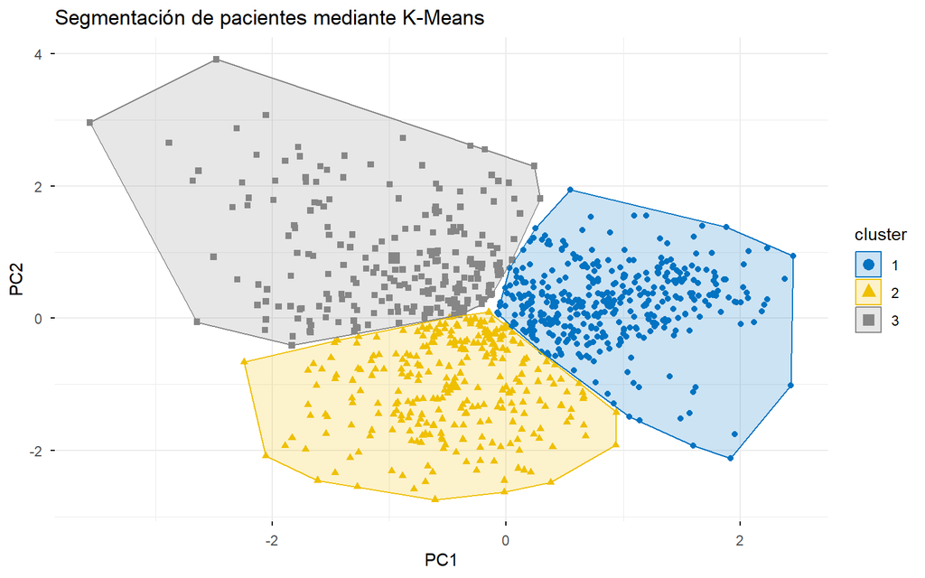

```r
fviz_cluster(
  kmeans_model,
  data = pca_scores[,1:2],
  geom = "point",
  ellipse.type = "convex",
  palette = "jco",
  ggtheme = theme_minimal()
) +
  labs(
    title = "Segmentación de pacientes mediante K-Means"
  )
```

```r
heart_cluster <- heart_clean

heart_cluster$cluster <- factor(kmeans_model$cluster)

cluster_summary <- heart_cluster %>%
  group_by(cluster) %>%
  summarise(
    Pacientes = n(),
    Edad = round(mean(age),2),
    Colesterol = round(mean(chol),2),
    Presion = round(mean(trestbps),2),
    Frecuencia = round(mean(thalch),2),
    Oldpeak = round(mean(oldpeak),2),
    Vasos = round(mean(ca),2),
    Enfermedad = round(mean(heart_disease),2)
  )

knitr::kable(
  cluster_summary,
  caption = "Características promedio de cada clúster"
)
```

Características promedio de cada clúster

| cluster | Pacientes | Edad | Colesterol | Presion | Frecuencia | Oldpeak | Vasos | Enfermedad |
| --- | --- | --- | --- | --- | --- | --- | --- | --- |
| 1 | 398 | 46.72 | 231.35 | 125.67 | 153.65 | 0.37 | 0.04 | 0.29 |
| 2 | 292 | 58.14 | 105.00 | 132.16 | 117.67 | 0.79 | 0.03 | 0.74 |
| 3 | 230 | 59.37 | 266.00 | 142.73 | 135.50 | 1.76 | 0.80 | 0.76 |

# 12 Interpretación de los clústeres

El algoritmo K-Means permitió segmentar a los pacientes en tres grupos con características clínicas diferenciadas, evidenciando distintos perfiles de riesgo cardiovascular.

El **Clúster 1** está conformado por 398 pacientes y representa el grupo con menor riesgo relativo. Sus integrantes presentan la menor edad promedio (46.7 años), la mayor frecuencia cardíaca máxima alcanzada (154 lpm) y el menor valor promedio de `oldpeak` (0.37). Además, únicamente el 29% de los pacientes de este grupo presentan enfermedad cardíaca, lo que sugiere un perfil clínico más favorable.

El **Clúster 2** agrupa a 292 pacientes con una edad promedio de 58.1 años. Aunque presenta el colesterol promedio más bajo (105 mg/dL), también muestra una frecuencia cardíaca máxima considerablemente menor (118 lpm) y una proporción de enfermedad cardíaca del 74%. Esto indica un grupo con un riesgo cardiovascular elevado que probablemente está influenciado por la combinación de múltiples factores clínicos.

El **Clúster 3** está compuesto por 230 pacientes y representa el grupo con el perfil de mayor riesgo. Presenta la mayor edad promedio (59.4 años), la presión arterial más elevada (143 mmHg), el colesterol promedio más alto (266 mg/dL), el mayor valor promedio de `oldpeak` (1.76) y la mayor cantidad promedio de vasos principales afectados (0.80). En este grupo, el 76% de los pacientes presentan enfermedad cardíaca.

En conjunto, los resultados demuestran que el algoritmo K-Means logró identificar segmentos de pacientes con características clínicas claramente diferenciadas, facilitando la identificación de perfiles de riesgo cardiovascular dentro del conjunto de datos analizado.

# 13 Hallazgos principales

A partir del análisis realizado se identificaron los siguientes hallazgos relevantes:

- El conjunto de datos presentó una calidad adecuada para el análisis, aunque fue necesario realizar un proceso de limpieza e imputación de valores faltantes en algunas variables clínicas.
- La exploración inicial permitió identificar una distribución relativamente equilibrada entre pacientes con y sin enfermedad cardíaca, favoreciendo el desarrollo del análisis.
- Variables como la frecuencia cardíaca máxima (`thalch`), el número de vasos principales afectados (`ca`) y la depresión del segmento ST (`oldpeak`) mostraron una mayor relación con la presencia de enfermedad cardíaca durante el análisis exploratorio y la matriz de correlación.
- El análisis de componentes principales permitió reducir la dimensionalidad del conjunto de datos, conservando aproximadamente el 50.52% de la variabilidad mediante las dos primeras componentes principales, lo que facilitó la representación visual de los pacientes.
- El algoritmo K-Means identificó tres grupos con perfiles clínicos claramente diferenciados, permitiendo distinguir pacientes con características de menor y mayor riesgo cardiovascular.
- La combinación de técnicas de análisis exploratorio, reducción de dimensionalidad y aprendizaje no supervisado permitió obtener una visión integral del comportamiento de los datos y descubrir patrones que no son evidentes mediante un análisis descriptivo tradicional.

# 14 Conclusiones

El desarrollo de este proyecto permitió aplicar de manera integral las principales etapas de un proceso de análisis de datos, desde la exploración inicial hasta la aplicación de técnicas de reducción de dimensionalidad y aprendizaje no supervisado.

El análisis exploratorio facilitó la comprensión de las características del conjunto de datos, permitiendo identificar variables con mayor relación respecto a la presencia de enfermedad cardíaca, así como detectar valores faltantes y realizar un proceso de limpieza que garantizó la calidad de la información utilizada.

La aplicación del Análisis de Componentes Principales (PCA) permitió reducir la dimensionalidad del conjunto de datos, conservando una parte importante de la variabilidad original y facilitando la visualización de los pacientes en un espacio bidimensional.

Posteriormente, el algoritmo K-Means logró identificar tres grupos de pacientes con perfiles clínicos diferenciados, evidenciando distintos niveles de riesgo cardiovascular. Estos resultados demuestran que las técnicas de análisis exploratorio y aprendizaje no supervisado constituyen herramientas valiosas para descubrir patrones ocultos y apoyar la interpretación de información médica.

En términos generales, el proyecto permitió transformar un conjunto de datos clínicos en información útil para comprender mejor las características de los pacientes y apoyar futuros procesos de análisis y toma de decisiones basadas en datos.